# 491PS7

Ramsey EL Lethy

2025-04-14

# Question 1 (concept)[16p (=8+8)]

## This question relates to the plots in Figure 1.

### (a) Sketch the tree corresponding to the partition of the predictor space illustrated in the left-hand panel of Figure 1. The numbers inside the boxes indicate the mean of Y within each region.

[figure not shown]

Tree

### (b) Create a diagram similar to the left-hand panel of Figure 1, using the tree illustrated in the right-hand panel of the same figure. You should divide up the predictor space into the correct regions, and indicate the mean for each region.

[figure not shown]

Tree

# Question 2 (applied)[60p (=0+6×10)]

## This problem involves the OJ data set which is part of the ISLR2 package.

### (a) Create a training set containing a random sample of 800 observations, and a test set containing the remaining observations.

```r
library(ISLR2)
set.seed(9)
data(OJ)

train_indices <- sample(1:nrow(OJ), 800)
OJ_train <- OJ[train_indices, ]

OJ_test <- OJ[-train_indices, ]

nrow(OJ_train)
```

```
## [1] 800
```

```r
nrow(OJ_test)
```

```
## [1] 270
```

### (b) Fit a tree to the training data, with Purchase as the response and the other vari- ables as predictors. Use the summary() function to produce summary statistics about the tree, and describe the results obtained. What is the training error rate? How many terminal nodes does the tree have?

```r
library(tree)

tree_OJ <- tree(Purchase ~ ., data = OJ_train)

summary(tree_OJ)
```

```
##
## Classification tree:
## tree(formula = Purchase ~ ., data = OJ_train)
## Variables actually used in tree construction:
## [1] "LoyalCH"       "PriceDiff"     "ListPriceDiff"
## Number of terminal nodes:  8
## Residual mean deviance:  0.7319 = 579.7 / 792
## Misclassification error rate: 0.1512 = 121 / 800
```

### (c) Type in the name of the tree object in order to get a detailed text output. Pick one of the terminal nodes, and interpret the information displayed.

```r
tree_OJ
```

```
## node), split, n, deviance, yval, (yprob)
##       * denotes terminal node
##
##  1) root 800 1053.000 CH ( 0.63125 0.36875 )
##    2) LoyalCH < 0.48285 288  321.700 MM ( 0.24653 0.75347 )
##      4) LoyalCH < 0.280875 159  120.300 MM ( 0.12579 0.87421 )
##        8) LoyalCH < 0.035047 53    9.922 MM ( 0.01887 0.98113 ) *
##        9) LoyalCH > 0.035047 106   99.690 MM ( 0.17925 0.82075 ) *
##      5) LoyalCH > 0.280875 129  173.100 MM ( 0.39535 0.60465 )
##       10) PriceDiff < 0.25 84   98.620 MM ( 0.27381 0.72619 ) *
##       11) PriceDiff > 0.25 45   59.670 CH ( 0.62222 0.37778 ) *
##    3) LoyalCH > 0.48285 512  437.000 CH ( 0.84766 0.15234 )
##      6) LoyalCH < 0.764572 252  297.800 CH ( 0.72222 0.27778 )
##       12) PriceDiff < -0.165 39   46.400 MM ( 0.28205 0.71795 ) *
##       13) PriceDiff > -0.165 213  211.500 CH ( 0.80282 0.19718 )
##         26) ListPriceDiff < 0.135 36   49.800 CH ( 0.52778 0.47222 ) *
##         27) ListPriceDiff > 0.135 177  144.200 CH ( 0.85876 0.14124 ) *
##      7) LoyalCH > 0.764572 260   71.450 CH ( 0.96923 0.03077 ) *
```

###(d) Create a plot of the tree, and interpret the results.

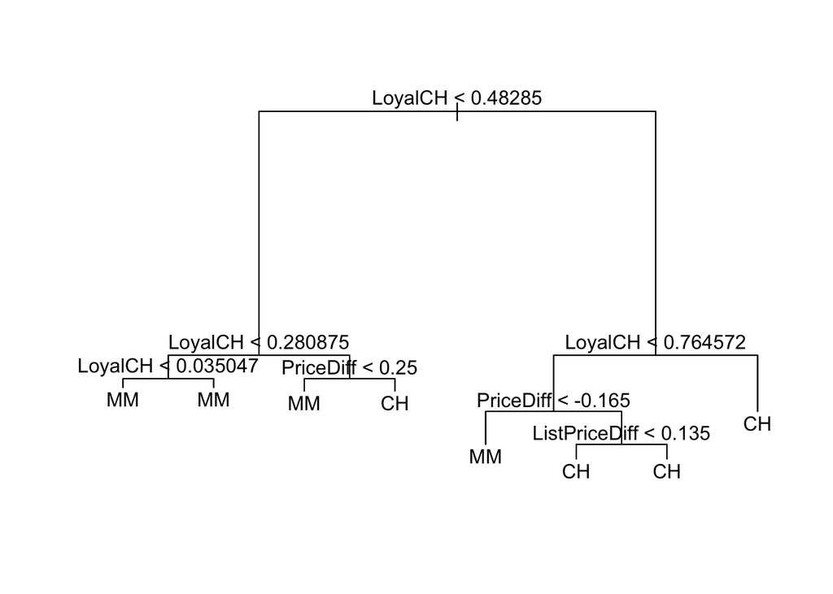

```r
par(mfrow = c(1,1))
plot(tree_OJ)
text(tree_OJ, pretty = 0)
```

### (e) Predict the response on the test data, and produce a confusion matrix comparing the test labels to the predicted test labels. What is the test error rate?

```r
tree_pred <- predict(tree_OJ, newdata = OJ_test, type = "class")

conf_matrix <- table(Predicted = tree_pred, Actual = OJ_test$Purchase)
conf_matrix
```

```
##          Actual
## Predicted  CH  MM
##        CH 132  37
##        MM  16  85
```

```r
test_error <- mean(tree_pred != OJ_test$Purchase)
test_error
```

```
## [1] 0.1962963
```

### (f) Apply the cv.tree() function to the training set in order to determine the optimal tree size.

```r
cv_OJ <- cv.tree(tree_OJ, FUN = prune.misclass)
cv_OJ
```

```
## $size
## [1] 8 6 4 2 1
##
## $dev
## [1] 143 143 149 154 295
##
## $k
## [1]  -Inf   0.0   5.5   8.5 146.0
##
## $method
## [1] "misclass"
##
## attr(,"class")
## [1] "prune"         "tree.sequence"
```

### (g) Produce a plot with tree size on the x-axis and cross-validated classification error rate on the y-axis.

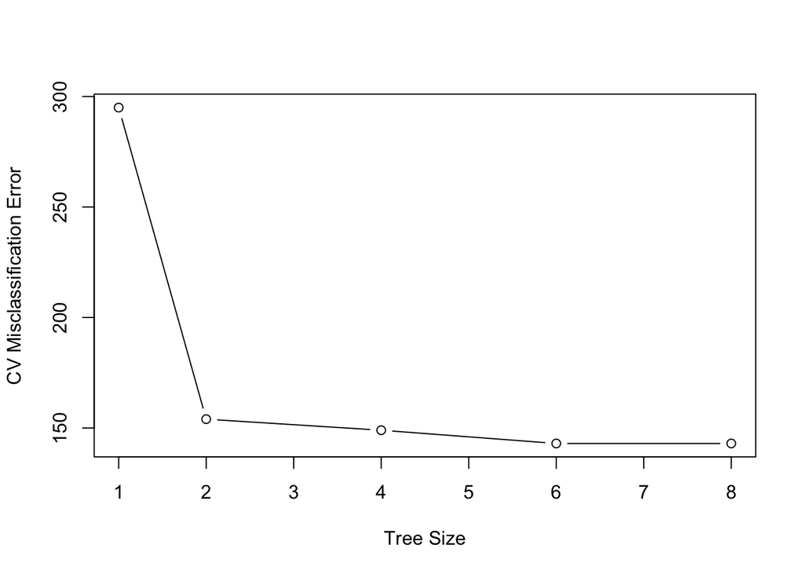

```r
plot(cv_OJ$size, cv_OJ$dev, type = "b",
     xlab = "Tree Size", ylab = "CV Misclassification Error")
```

### (i) Produce a pruned tree corresponding to the optimal tree size obtained using cross- validation. If cross-validation does not lead to selection of a pruned tree, then create a pruned tree with five terminal nodes.

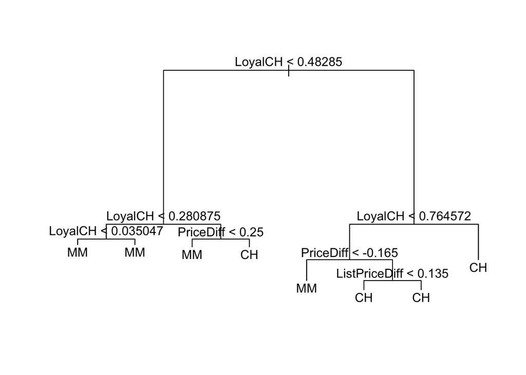

```r
best_size = 7
pruned_OJ <- prune.misclass(tree_OJ, best = best_size)

plot(pruned_OJ)
text(pruned_OJ, pretty = 0)
```

### (j) Compare the training error rates between the pruned and unpruned trees. Which is higher?

```r
train_pred_unpruned <- predict(tree_OJ, newdata = OJ_train, type = "class")
train_pred_pruned <- predict(pruned_OJ, newdata = OJ_train, type = "class")

train_err_unpruned <- mean(train_pred_unpruned != OJ_train$Purchase)
train_err_pruned <- mean(train_pred_pruned != OJ_train$Purchase)

train_err_unpruned
```

```
## [1] 0.15125
```

```r
train_err_pruned
```

```
## [1] 0.15125
```

###(k) Compare the test error rates between the pruned and unpruned trees. Which is higher?

```r
test_pred_pruned <- predict(pruned_OJ, newdata = OJ_test, type = "class")

test_err_pruned <- mean(test_pred_pruned != OJ_test$Purchase)

test_err_pruned
```

```
## [1] 0.1962963
```

```r
test_error
```

```
## [1] 0.1962963
```

# Question 3 (applied)[24p (=0+6+6+6+6)]

## In the lab, a classification tree is applied to the Carseats data set after converting Sales into a qualitative response variable. Now we will seek to predict Sales using regression trees and related approaches, treating the response as a quantitative variable.

### (a) Split the data set into a training set and a test set. (Hint: To be able to reproduce your results, do not forget to set the seed in your randomization using the command set.seed().)

```r
library(ISLR2)
library(tree)

set.seed(9)

data(Carseats)
train_indices <- sample(1:nrow(Carseats), 200)
Carseats_train <- Carseats[train_indices, ]
Carseats_test <- Carseats[-train_indices, ]
```

### (b) Fit a regression tree to the training set. Plot the tree, and interpret the results. What test MSE do you obtain?

```r
tree_carseats <- tree(Sales ~ ., data = Carseats_train)
summary(tree_carseats)
```

```
##
## Regression tree:
## tree(formula = Sales ~ ., data = Carseats_train)
## Variables actually used in tree construction:
## [1] "ShelveLoc"   "Price"       "CompPrice"   "Age"         "Advertising"
## Number of terminal nodes:  16
## Residual mean deviance:  2.331 = 428.8 / 184
## Distribution of residuals:
##     Min.  1st Qu.   Median     Mean  3rd Qu.     Max.
## -4.04200 -0.90650  0.05187  0.00000  0.99000  4.44700
```

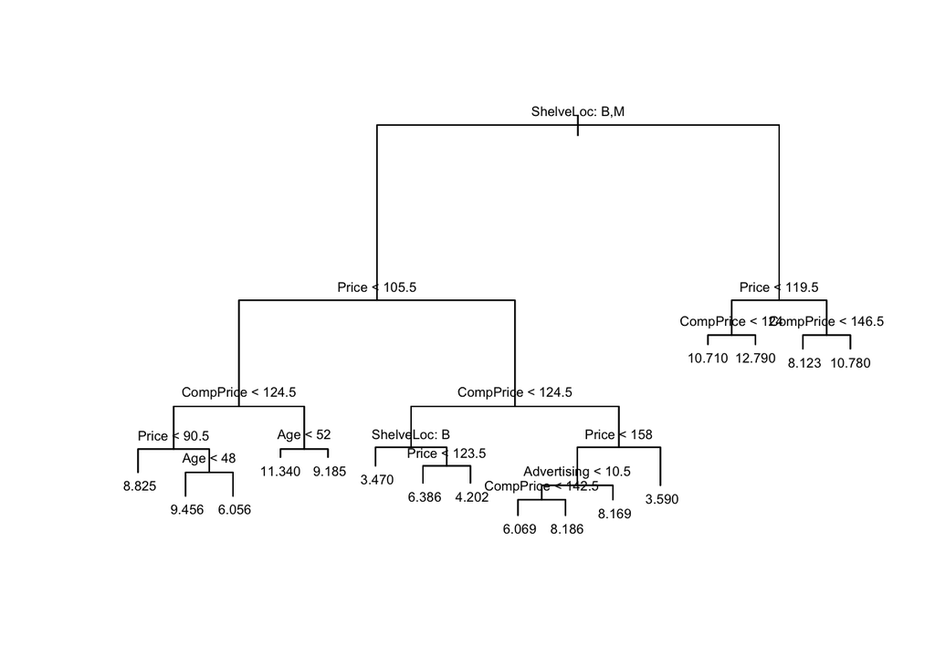

```r
plot(tree_carseats)
text(tree_carseats, pretty = 1, cex = 0.6)
```

```r
sales <- predict(tree_carseats, newdata = Carseats_test)

test_mse <- mean((sales - Carseats_test$Sales)^2)

test_mse
```

```
## [1] 4.908031
```

### (c) Use cross-validation in order to determine the optimal level of tree complexity. Does pruning the tree improve the test MSE?

```r
cv_carseats <- cv.tree(tree_carseats)

cv_carseats
```

```
## $size
##  [1] 16 15 14 13 11 10  9  7  6  5  4  3  2  1
##
## $dev
##  [1] 1057.732 1071.996 1090.472 1195.154 1172.654 1197.947 1186.112 1203.709
##  [9] 1234.278 1224.284 1208.030 1211.329 1275.515 1587.421
##
## $k
##  [1]      -Inf  15.99634  18.21667  26.89137  29.29647  33.55257  36.36432
##  [8]  45.95447  68.17619  74.54199  79.80160  83.32391 207.71514 342.75304
##
## $method
## [1] "deviance"
##
## attr(,"class")
## [1] "prune"         "tree.sequence"
```

```r
best_size <- cv_carseats$size[which.min(cv_carseats$dev)]
best_size
```

```
## [1] 16
```

```r
pruned_tree <- prune.tree(tree_carseats, best = best_size)


pruned_pred <- predict(pruned_tree, newdata = Carseats_test)

pruned_test_mse <- mean((pruned_pred - Carseats_test$Sales)^2)

pruned_test_mse
```

```
## [1] 4.908031
```

### (d) Use the bagging approach in order to analyze this data. What test MSE do you obtain? Use the importance() function to determine which variables are most important.

```r
library(randomForest)
bagged_model <- randomForest(Sales ~ ., data = Carseats_train,
                             mtry = ncol(Carseats_train) - 1,
                             importance = TRUE)

bagged_pred <- predict(bagged_model, newdata = Carseats_test)
bagged_test_mse <- mean((bagged_pred - Carseats_test$Sales)^2)
bagged_test_mse
```

```
## [1] 2.780947
```

```r
importance(bagged_model)
```

```
##                %IncMSE IncNodePurity
## CompPrice   26.8550711    197.163287
## Income       5.0438451     73.299130
## Advertising 18.3405705    177.393435
## Population  -2.7279971     57.896286
## Price       54.9296724    466.139433
## ShelveLoc   52.8551288    372.105412
## Age         13.7209793    123.970950
## Education    1.4159299     39.905677
## Urban       -0.3510158      5.274094
## US           0.9589852      7.586639
```

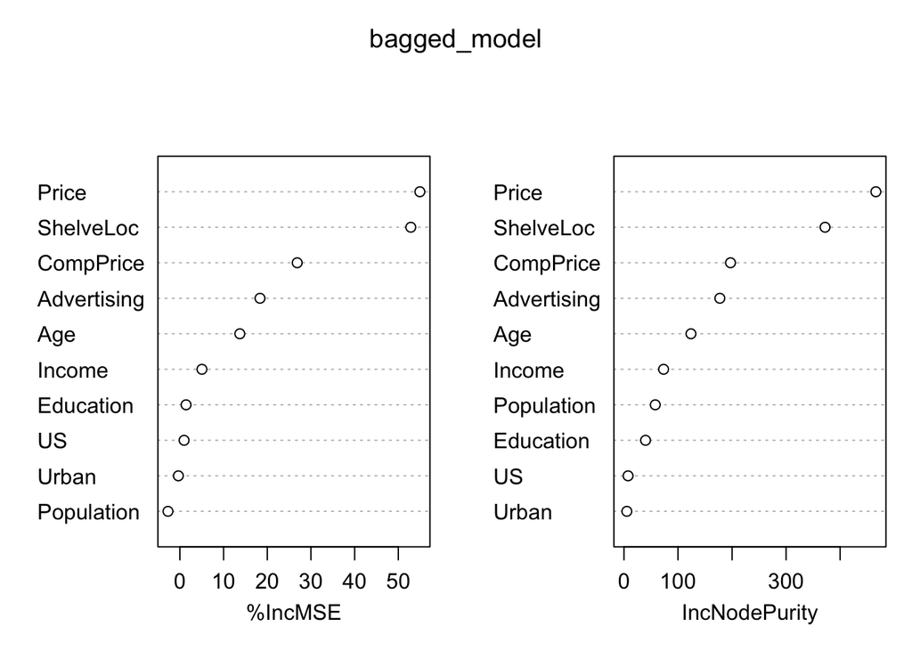

```r
varImpPlot(bagged_model)
```

bagging so far has done the best job at reducing the error in predicting unseen values

### (e) Use random forests to analyze this data. What test MSE do you obtain? Use the importance() function to determine which variables are most important. Describe the effect of m, the number of variables considered at each split, on the error rate obtained.

```r
rf <- randomForest(Sales ~ ., data = Carseats_train, importance = TRUE)

rf_pred <- predict(rf, newdata = Carseats_test)

rf_test_mse <- mean((rf_pred - Carseats_test$Sales)^2)
rf_test_mse
```

```
## [1] 3.200015
```

```r
importance(rf)
```

```
##                %IncMSE IncNodePurity
## CompPrice   15.9193175     163.11113
## Income       4.5859583     117.36383
## Advertising 16.2995767     163.03492
## Population  -0.5452161     104.64368
## Price       35.6509888     378.53190
## ShelveLoc   35.6979774     304.76706
## Age          9.6291322     154.14185
## Education    1.3750096      64.99985
## Urban       -0.1185826      14.82990
## US           3.2265789      20.35110
```

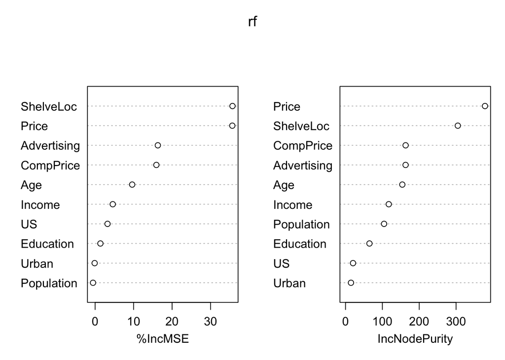

```r
varImpPlot(rf)
```

Looks like once again ShelveLoc and Price are flying out the gate with how much of an impact it has on our model when we split on them.

It looks like the Test MSE for rf is just a bit bigger than bagging, so bagging would be our most optimal choice in this data.